# Home_work_5

Тимофеев Игорь, 391 гр.

7 декабря 2016 г

# Линейная регрессия, экспоненциальное сглаживание. Анализ.

# Первая линейная модель

Первой моделью будет линейная модель в зависимости от 13 переменных, 12 месяцев и времени.

Вот исходный график:

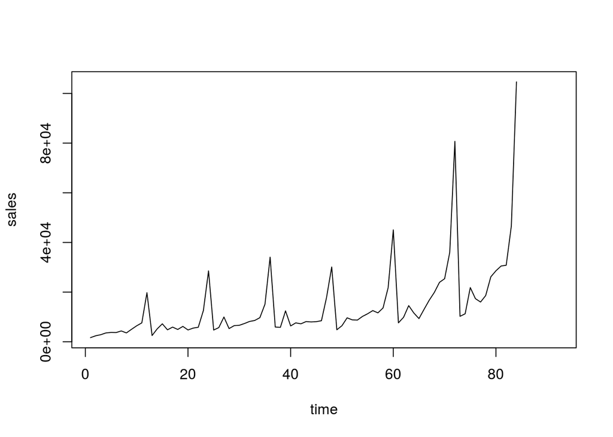

Видно, что сезонность мультипликативная, чтобы сделать ее аддитивной, нужно применить логарифм.

Построим график логарифма.

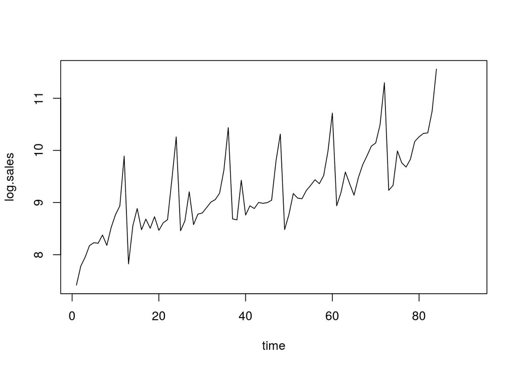

Видно, что сезонность стала аддитивной, что подтверждает, что у изначального ряда была мультипликативная.

Нам нужна модель вида:

$y=a + b*t + \sum_{i=1}^{12}{month.i}$

Но при этом возникнут проблемы с линейной зависиомстью между переменными, так как month.i это вектора из 12 элементов, 11 из которых 0, а i равен 1, т.е. в сумме они дают вектор из единиц. Чтобы это исправить положение можно запихнуть поправку одного из месяцев в свободный член, тогда при интерпретации результатов a это будет значение в выбранном нами месяце, а в остальных переменных месяцов значение разницы между значением этого месяца и выбранного.

Получается такая модель:

```
##
## Call:
## lm(formula = log.sales ~ time + month.02 + month.03 + month.04 +
##     month.05 + month.06 + month.07 + month.08 + month.09 + month.10 +
##     month.11 + month.12, data = df)
##
## Residuals:
##     Min      1Q  Median      3Q     Max
## -0.4166 -0.1262  0.0061  0.1139  0.3858
##
## Coefficients:
##              Estimate Std. Error t value Pr(>|t|)
## (Intercept) 7.6056596  0.0768824  98.926  < 2e-16 ***
## time        0.0223946  0.0008449  26.507  < 2e-16 ***
## month.02    0.2510893  0.0993387   2.528 0.013712 *
## month.03    0.6952746  0.0993495   6.998 1.18e-09 ***
## month.04    0.3830106  0.0993674   3.854 0.000252 ***
## month.05    0.4080384  0.0993926   4.105 0.000106 ***
## month.06    0.4470141  0.0994249   4.496 2.63e-05 ***
## month.07    0.6082946  0.0994643   6.116 4.69e-08 ***
## month.08    0.5854400  0.0995110   5.883 1.21e-07 ***
## month.09    0.6664262  0.0995648   6.693 4.26e-09 ***
## month.10    0.7441158  0.0996257   7.469 1.61e-10 ***
## month.11    1.2031117  0.0996937  12.068  < 2e-16 ***
## month.12    1.9582492  0.0997689  19.628  < 2e-16 ***
## ---
## Signif. codes:  0 '***' 0.001 '**' 0.01 '*' 0.05 '.' 0.1 ' ' 1
##
## Residual standard error: 0.1858 on 71 degrees of freedom
##   (8 observations deleted due to missingness)
## Multiple R-squared:  0.9527, Adjusted R-squared:  0.9447
## F-statistic: 119.1 on 12 and 71 DF,  p-value: < 2.2e-16
```

# Улучшение первой линейной модели.

Линейная модель должна удовлетворять нескольким условиям:

1)Выбрана правильная спецификация, в нашем случае нужно проверить дает ли сильное улучшение, если кроме переменной time в модели, мы добавим переменную time**2, а также насколько сильно влияют на модель различные месяцы.

В нашем случае и так видно, что тренд линейный.

2)Переменные модели не должны коррелировать между собой.

3)Гомоскедастичность.

4)Отствие автокорреляции случайных ошибок.

5)Нормальность распределения ошибок.

В нашей модели всего 84 наблюдения, а переменных 12. Это слишком много, есть правило, что на каждую переменную должно приходится по 30 наблюдений, в нашем случае на каждую переменную приходится 7 наблюдений. А слишком “хорошая” модель может привести к переобучению. Поэтому нужно как-то поудалять переменные.

Вспомним, что получилось в первой модели.

```
##
## Call:
## lm(formula = log.sales ~ time + month.02 + month.03 + month.04 +
##     month.05 + month.06 + month.07 + month.08 + month.09 + month.10 +
##     month.11 + month.12)
##
## Residuals:
##     Min      1Q  Median      3Q     Max
## -0.4166 -0.1262  0.0061  0.1139  0.3858
##
## Coefficients:
##              Estimate Std. Error t value Pr(>|t|)
## (Intercept) 7.6056596  0.0768824  98.926  < 2e-16 ***
## time        0.0223946  0.0008449  26.507  < 2e-16 ***
## month.02    0.2510893  0.0993387   2.528 0.013712 *
## month.03    0.6952746  0.0993495   6.998 1.18e-09 ***
## month.04    0.3830106  0.0993674   3.854 0.000252 ***
## month.05    0.4080384  0.0993926   4.105 0.000106 ***
## month.06    0.4470141  0.0994249   4.496 2.63e-05 ***
## month.07    0.6082946  0.0994643   6.116 4.69e-08 ***
## month.08    0.5854400  0.0995110   5.883 1.21e-07 ***
## month.09    0.6664262  0.0995648   6.693 4.26e-09 ***
## month.10    0.7441158  0.0996257   7.469 1.61e-10 ***
## month.11    1.2031117  0.0996937  12.068  < 2e-16 ***
## month.12    1.9582492  0.0997689  19.628  < 2e-16 ***
## ---
## Signif. codes:  0 '***' 0.001 '**' 0.01 '*' 0.05 '.' 0.1 ' ' 1
##
## Residual standard error: 0.1858 on 71 degrees of freedom
##   (8 observations deleted due to missingness)
## Multiple R-squared:  0.9527, Adjusted R-squared:  0.9447
## F-statistic: 119.1 on 12 and 71 DF,  p-value: < 2.2e-16
```

Можно предположить, что некоторые из месяцов не слишком сильно отличаются и их можно объединить в один, для это нужно взять за базовый месяц один из них и посмотреть на p-value. Подозрение падает на 7-8 месяцы, возьмем за базис 7.

```
##
## Call:
## lm(formula = log.sales ~ time + month.01 + month.02 + month.03 +
##     month.04 + month.05 + month.06 + month.08 + month.09 + month.10 +
##     month.11 + month.12)
##
## Residuals:
##     Min      1Q  Median      3Q     Max
## -0.4166 -0.1262  0.0061  0.1139  0.3858
##
## Coefficients:
##               Estimate Std. Error t value Pr(>|t|)
## (Intercept)  8.2139542  0.0790793 103.870  < 2e-16 ***
## time         0.0223946  0.0008449  26.507  < 2e-16 ***
## month.01    -0.6082946  0.0994643  -6.116 4.69e-08 ***
## month.02    -0.3572052  0.0994249  -3.593   0.0006 ***
## month.03     0.0869800  0.0993926   0.875   0.3845
## month.04    -0.2252840  0.0993674  -2.267   0.0264 *
## month.05    -0.2002561  0.0993495  -2.016   0.0476 *
## month.06    -0.1612804  0.0993387  -1.624   0.1089
## month.08    -0.0228546  0.0993387  -0.230   0.8187
## month.09     0.0581316  0.0993495   0.585   0.5603
## month.10     0.1358212  0.0993674   1.367   0.1760
## month.11     0.5948171  0.0993926   5.985 8.02e-08 ***
## month.12     1.3499547  0.0994249  13.578  < 2e-16 ***
## ---
## Signif. codes:  0 '***' 0.001 '**' 0.01 '*' 0.05 '.' 0.1 ' ' 1
##
## Residual standard error: 0.1858 on 71 degrees of freedom
##   (8 observations deleted due to missingness)
## Multiple R-squared:  0.9527, Adjusted R-squared:  0.9447
## F-statistic: 119.1 on 12 and 71 DF,  p-value: < 2.2e-16
```

Подозрение оправдалось, даже более того, за один месяц можно взять 6,7,8,9 и 10.

Вот получившаяся при этом модель:

```
##
## Call:
## lm(formula = log.sales ~ time + month.02 + month.03 + month.04 +
##     month.05 + No_summer + month.11 + month.12)
##
## Residuals:
##      Min       1Q   Median       3Q      Max
## -0.41317 -0.12904 -0.02151  0.11720  0.38802
##
## Coefficients:
##              Estimate Std. Error t value Pr(>|t|)
## (Intercept) 7.6021727  0.0797833  95.285  < 2e-16 ***
## time        0.0224888  0.0008762  25.666  < 2e-16 ***
## month.02    0.2509951  0.1030991   2.435 0.017291 *
## month.03    0.6950861  0.1031102   6.741 2.83e-09 ***
## month.04    0.3827278  0.1031289   3.711 0.000394 ***
## month.05    0.4076615  0.1031549   3.952 0.000174 ***
## No_summer   0.6095984  0.0800925   7.611 6.53e-11 ***
## month.11    1.2021693  0.1034670  11.619  < 2e-16 ***
## month.12    1.9572126  0.1035449  18.902  < 2e-16 ***
## ---
## Signif. codes:  0 '***' 0.001 '**' 0.01 '*' 0.05 '.' 0.1 ' ' 1
##
## Residual standard error: 0.1929 on 75 degrees of freedom
##   (8 observations deleted due to missingness)
## Multiple R-squared:  0.9462, Adjusted R-squared:  0.9404
## F-statistic: 164.8 on 8 and 75 DF,  p-value: < 2.2e-16
```

Теперь првоерим 4 и 5. Возьмем за базис 4.

```
##
## Call:
## lm(formula = log.sales ~ time + month.02 + month.03 + month.01 +
##     month.05 + No_summer + month.11 + month.12)
##
## Residuals:
##      Min       1Q   Median       3Q      Max
## -0.41317 -0.12904 -0.02151  0.11720  0.38802
##
## Coefficients:
##               Estimate Std. Error t value Pr(>|t|)
## (Intercept)  7.9849006  0.0808871  98.717  < 2e-16 ***
## time         0.0224888  0.0008762  25.666  < 2e-16 ***
## month.02    -0.1317328  0.1031102  -1.278 0.205334
## month.03     0.3123582  0.1030991   3.030 0.003357 **
## month.01    -0.3827278  0.1031289  -3.711 0.000394 ***
## month.05     0.0249336  0.1030991   0.242 0.809563
## No_summer    0.2268706  0.0799342   2.838 0.005833 **
## month.11     0.8194414  0.1032776   7.934 1.59e-11 ***
## month.12     1.5744847  0.1033334  15.237  < 2e-16 ***
## ---
## Signif. codes:  0 '***' 0.001 '**' 0.01 '*' 0.05 '.' 0.1 ' ' 1
##
## Residual standard error: 0.1929 on 75 degrees of freedom
##   (8 observations deleted due to missingness)
## Multiple R-squared:  0.9462, Adjusted R-squared:  0.9404
## F-statistic: 164.8 on 8 and 75 DF,  p-value: < 2.2e-16
```

Снова получилось, возьмем за одну переменную 4 и 5. Также можно объединить 1 и 2.

```
##
## Call:
## lm(formula = log.sales ~ time + Jan + month.03 + May + No_summer +
##     month.11)
##
## Residuals:
##      Min       1Q   Median       3Q      Max
## -0.41245 -0.13563  0.00398  0.12049  0.51398
##
## Coefficients:
##               Estimate Std. Error t value Pr(>|t|)
## (Intercept)  9.5584287  0.0863107 110.744  < 2e-16 ***
## time         0.0225087  0.0008985  25.051  < 2e-16 ***
## Jan         -1.8315058  0.0920493 -19.897  < 2e-16 ***
## month.03    -1.2619471  0.1060384 -11.901  < 2e-16 ***
## May         -1.5618685  0.0918122 -17.012  < 2e-16 ***
## No_summer   -1.3475344  0.0819766 -16.438  < 2e-16 ***
## month.11    -0.7550234  0.1057334  -7.141 4.49e-10 ***
## ---
## Signif. codes:  0 '***' 0.001 '**' 0.01 '*' 0.05 '.' 0.1 ' ' 1
##
## Residual standard error: 0.1978 on 77 degrees of freedom
##   (8 observations deleted due to missingness)
## Multiple R-squared:  0.9419, Adjusted R-squared:  0.9373
## F-statistic: 207.9 on 6 and 77 DF,  p-value: < 2.2e-16
```

Получилась такая модель. При этом R квадрат изменился не слишком сильно, в первой модели он был 0.9447, в новой 0.9373. Нарисуем то, что она предсказывает(желтым цветом - данные, черным - предсказания модели на 92 месяца, т.е. и на стырые месяцы и на новые 8).

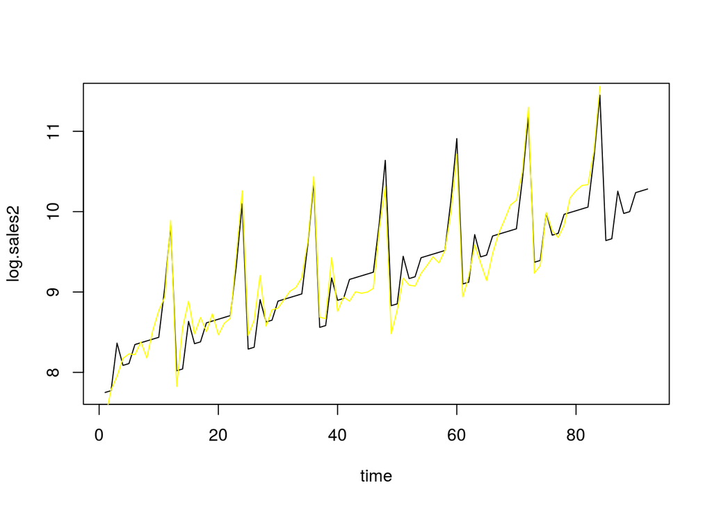

Теперь проверим другие пункты плана.

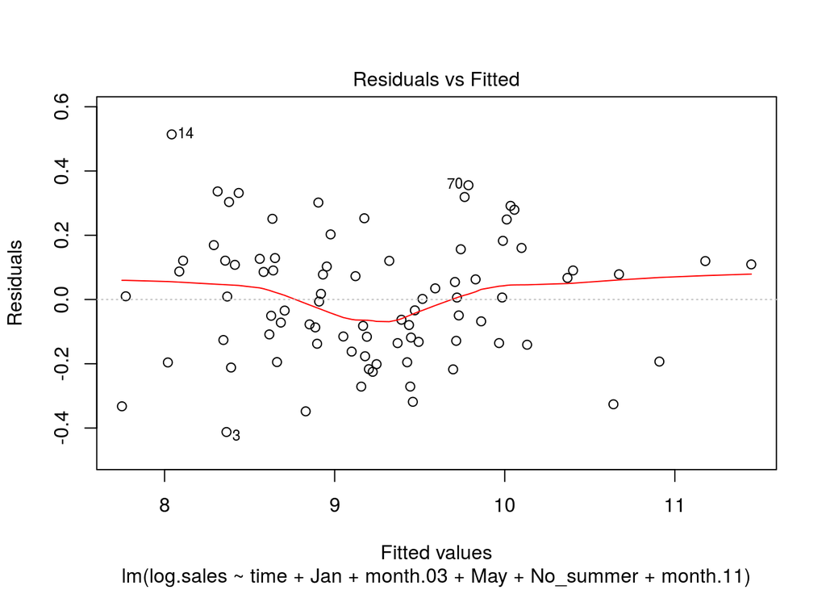

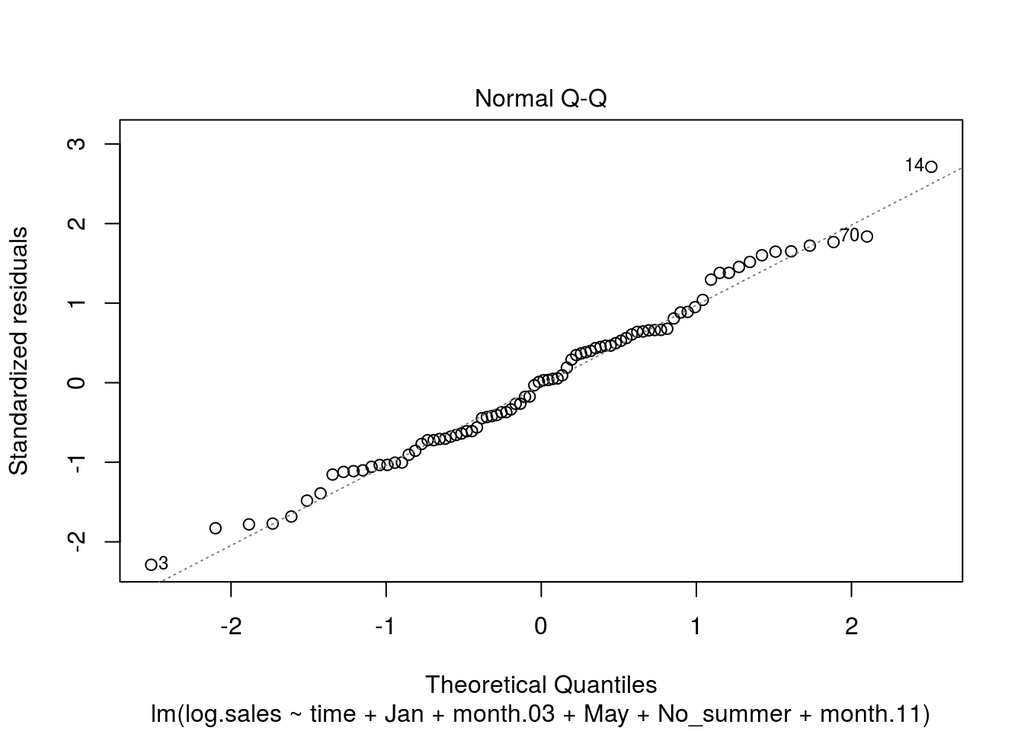

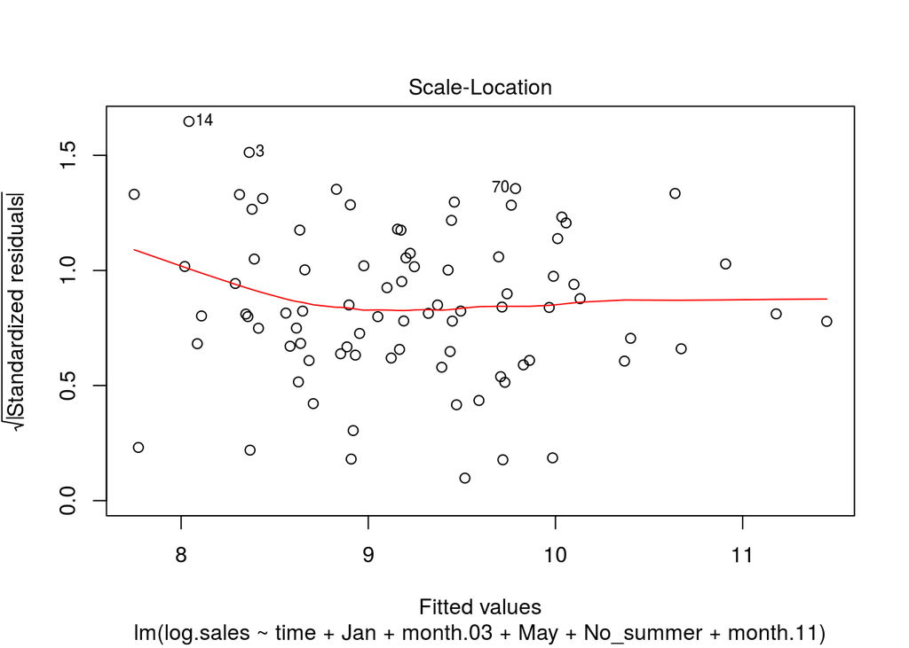

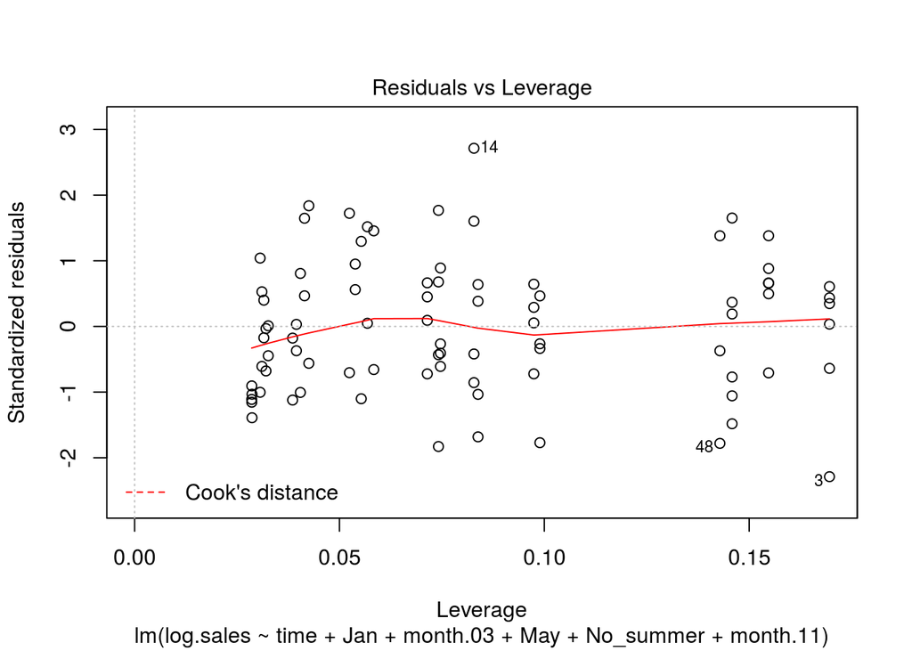

На последнем графике видно, что сильных выбросов нет.

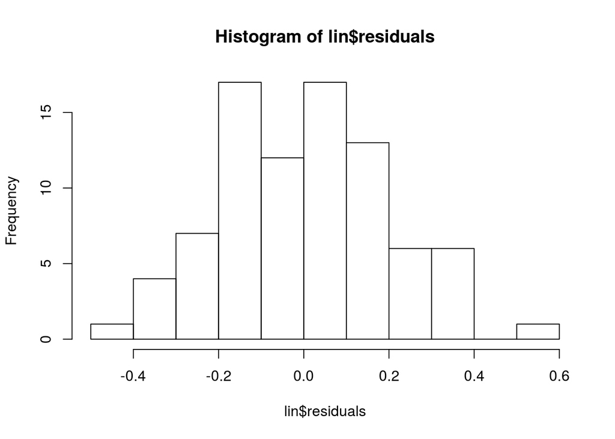

```
##
##  Shapiro-Wilk normality test
##
## data:  lin$residuals
## W = 0.98741, p-value = 0.5922
```

Шапиро тест показал, что распределение ошибок - нормальное.

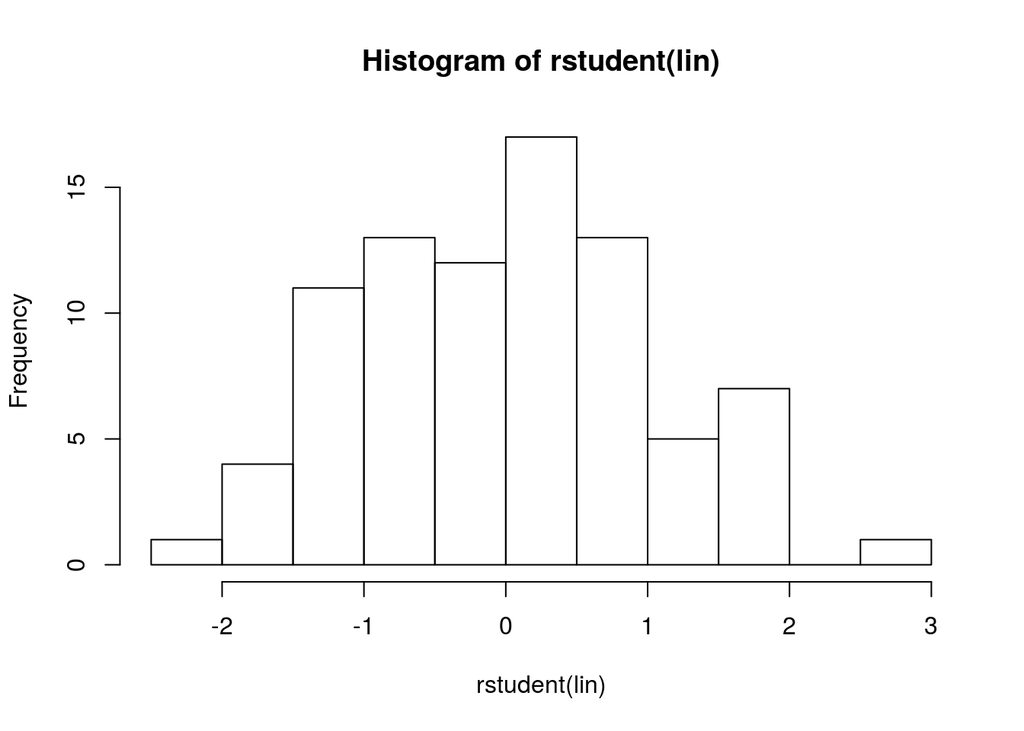

```
##
##  Shapiro-Wilk normality test
##
## data:  rstudent(lin)
## W = 0.98861, p-value = 0.6747
```

Немного улучшили показания Шапиро теста, убрав зависимость ошибок от иксов.

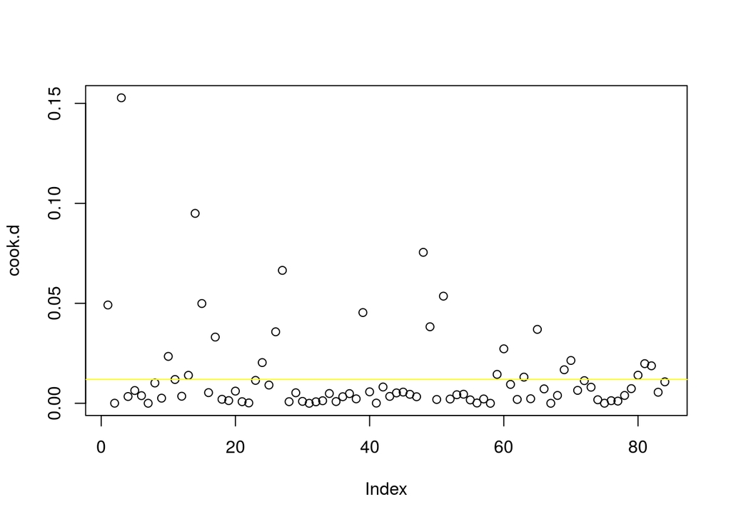

Опять же смотрим на наличие точек, являющихся выбросами. Красной линии вообще нет на графике, за желтую выходит слишком много, так что убирать их все смысла не имеет. Хотя можно было бы убрать одно наблюдение наиболее сильно отклоняющееся от модели, т.к. оно также по крайней мере визуально сильно отклоняется от остальных, но в нашем случае погоды это не изменит.

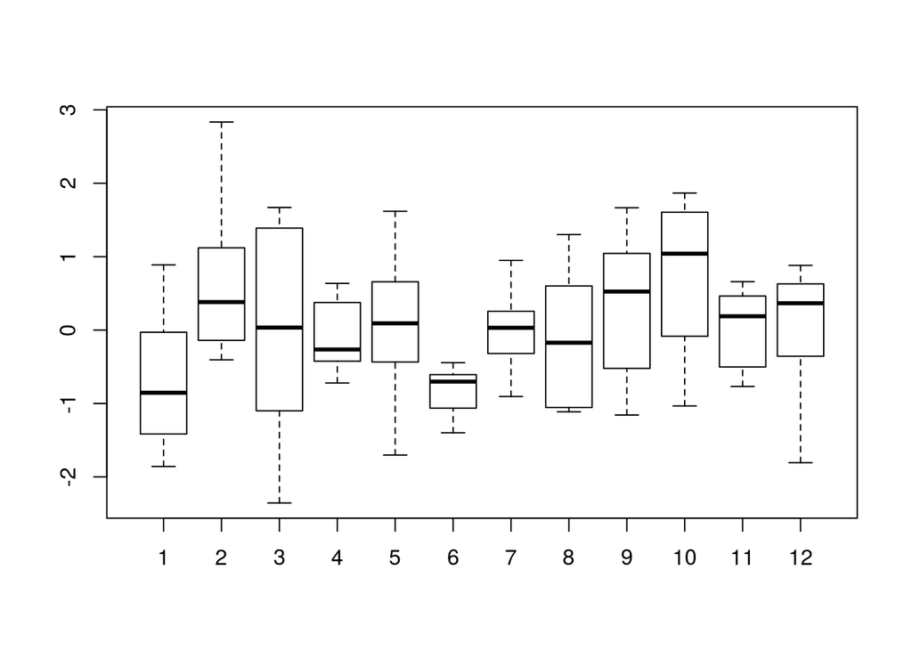

Еще один график, рисующий boxplot для различных месяцев.

Теперь проверим на автокорреляцию случайных ошибок.

```
##  lag Autocorrelation D-W Statistic p-value
##    1       0.3894214      1.180505       0
##  Alternative hypothesis: rho != 0
```

По результатам теста видно, что автокорреляция есть и очень сильная.

Что с этим делать непонятно. В рамках метода линейной регрессии это, по видимому, никак не исправить.

Теперь, наконец, вернемся к изначальному ряду и посмотрим, что предсказал метод.

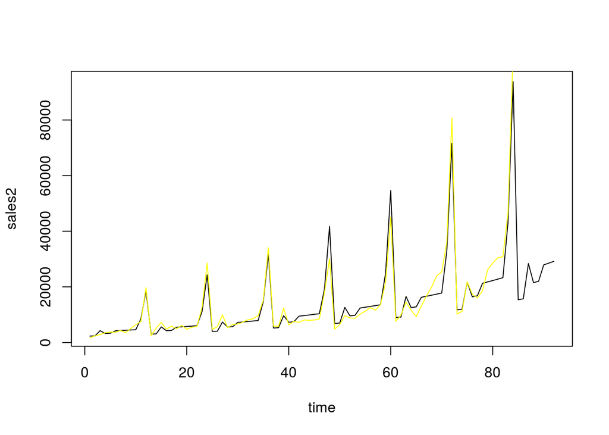

Вроде даже неплохо предсказывает данные, по крайней мере основные изменения.

```
##     sales    sales2
## 1    1664  2320.253
## 2    2397  2373.072
## 3    2840  4289.853
## 4    3547  3250.601
## 5    3752  3324.598
## 6    3714  4213.070
## 7    4349  4308.976
## 8    3566  4407.065
## 9    5021  4507.388
## 10   6423  4609.994
## 11   7600  8527.074
## 12  19756 18555.726
## 13   2499  3039.768
## 14   5198  3108.966
```

[output cut: 78 more lines]

Средняя ошибка составила: 14.7726687 процентов.

# Экспоненциальное сглаживание.

Предсказания модели:

```
##             xhat     level     trend    season
## Jan 2   2093.627  5366.039 155.82037 0.3791526
## Feb 2   4816.193  6044.490 180.14664 0.7737308
## Mar 2   7085.717  6465.854 191.37430 1.0643643
## Apr 2   4899.679  6721.197 194.35175 0.7085018
## May 2   5961.819  6850.915 191.34335 0.8465776
## Jun 2   4718.960  7006.564 189.68190 0.6557531
## Jul 2   6003.312  7369.218 197.73304 0.7933595
## Aug 2   4985.454  7675.201 202.77160 0.6328347
## Sep 2   6673.532  7697.643 194.37804 0.8456050
## Oct 2   7669.439  7211.315 162.69400 1.0400637
## Nov 2   7979.146  6511.829 122.56312 1.2026945
## Dec 2  26667.800  8512.504 209.98140 3.0573625
## Jan 3   3805.880  9021.982 223.92171 0.4116287
## Feb 3   8506.401 10327.898 274.28400 0.8023256
## Mar 3   9764.488  8893.567 194.75512 1.0743994
## Apr 3   6579.946  9175.910 198.83200 0.7018802
## May 3   7280.528  8486.106 157.46969 0.8423051
## Jun 3   5584.156  8185.958 136.16953 0.6710010
## Jul 3   7445.662  9084.029 171.63282 0.8044441
## Aug 3   5789.468  9196.924 168.89883 0.6181484
## Sep 3   8822.642 11253.072 256.74238 0.7665321
## Oct 3  10482.250 11350.615 249.33232 0.9036464
## Nov 3  16708.509 11171.380 229.38432 1.4655603
## Dec 3  35010.035 10881.270 205.20400 3.1579054
## Jan 4   5060.508 10939.568 198.36617 0.4543489
## Feb 4   7993.784 12063.723 241.45776 0.6496275
## Mar 4  11745.847 10664.955 165.11210 1.0845591
## Apr 4   7117.072 11134.368 179.27604 0.6290699
## May 4   8660.400 10732.345 152.21901 0.7956588
## Jun 4   7529.718 10238.619 122.15297 0.7267526
## Jul 4   8207.550 10155.140 112.58168 0.7993545
## Aug 4   7442.684 10214.795 110.11813 0.7208472
## Sep 4   8175.351 10688.603 127.04640 0.7558816
## Oct 4   9464.084 10762.394 124.56755 0.8693044
## Nov 4  14562.919 10331.343  98.70585 1.3962465
## Dec 4  36632.268 11603.264 153.31409 3.1158955
## Jan 5   5299.419 10733.982 105.71654 0.4888899
## Feb 5   5754.336 10366.341  83.68372 0.5506529
## Mar 5  12474.360 11085.335 113.25474 1.1139224
```

[output cut: 18 more lines]

```
## Oct 6  23101.279 26850.588 653.40473 0.8399246
## Nov 6  42162.023 28836.584 715.43128 1.4267055
## Dec 6  80109.807 27448.969 617.54326 2.8542844
## Jan 7  13559.289 28171.185 622.41537 0.4709133
## Feb 7  15245.698 25351.163 462.18428 0.5906130
## Mar 7  20922.124 22519.513 308.87006 0.9164961
## Apr 7  16836.352 23310.478 331.30959 0.7121438
## May 7  15515.572 23999.169 347.94418 0.6372654
## Jun 7  20487.639 24716.402 365.13302 0.8168415
## Jul 7  22070.864 23952.504 312.58138 0.9095729
## Aug 7  24719.547 26459.999 414.74540 0.9198059
## Sep 7  26017.740 28929.552 510.38812 0.8837566
## Oct 7  28589.249 31921.948 625.91521 0.8783756
## Nov 7  45450.650 33789.859 683.72493 1.3184196
## Dec 7 102033.747 34912.331 704.14676 2.8647905
```

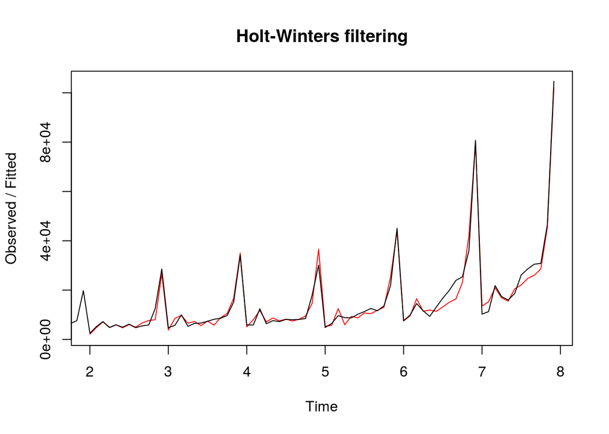

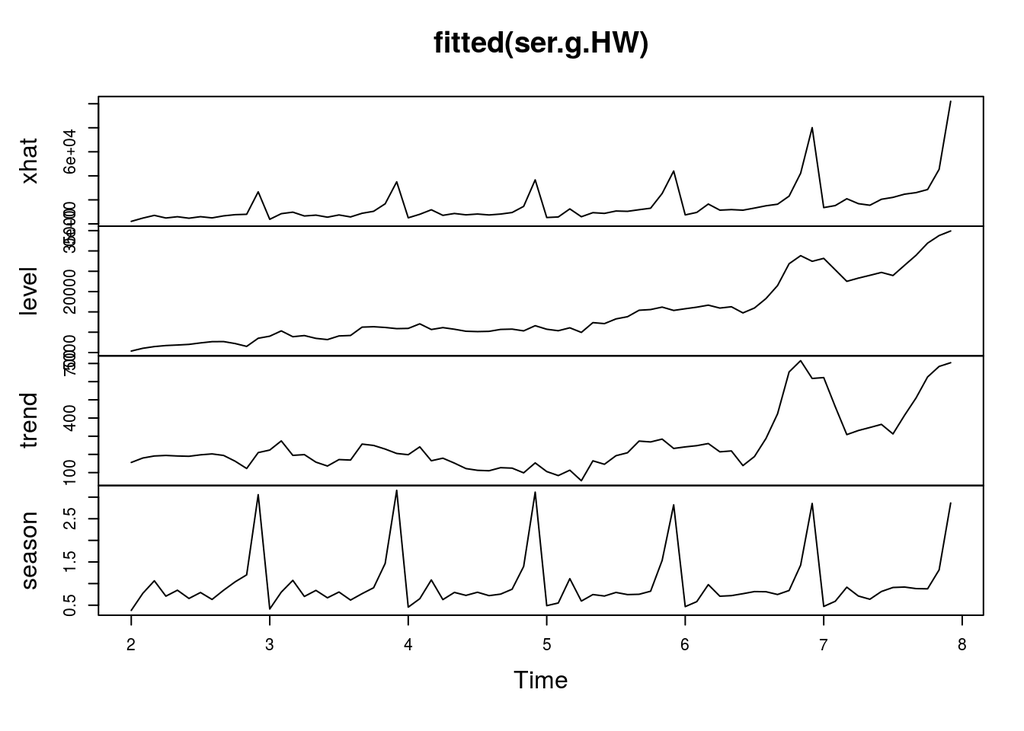

```
##        Jan      Feb      Mar      Apr      May      Jun      Jul      Aug
## 8 14994.22 18946.20 35764.49 28157.76 25667.19 31470.84 40494.46 41216.83
```

Средняя ошибка составила: 11.6329727 процентов. Теперь можно сранить основные итоговые графики экспоненциальной и линейной модели:

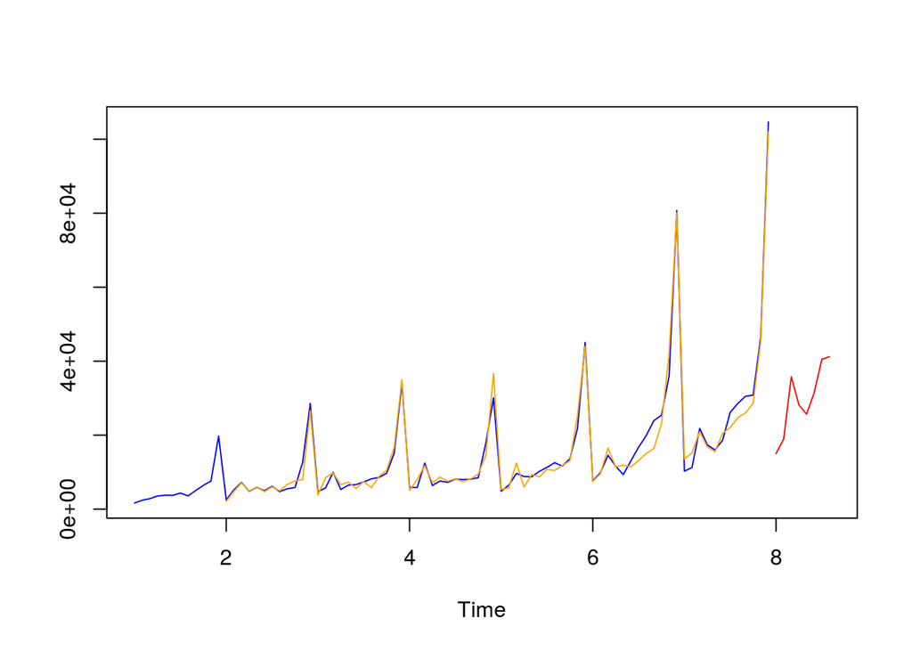

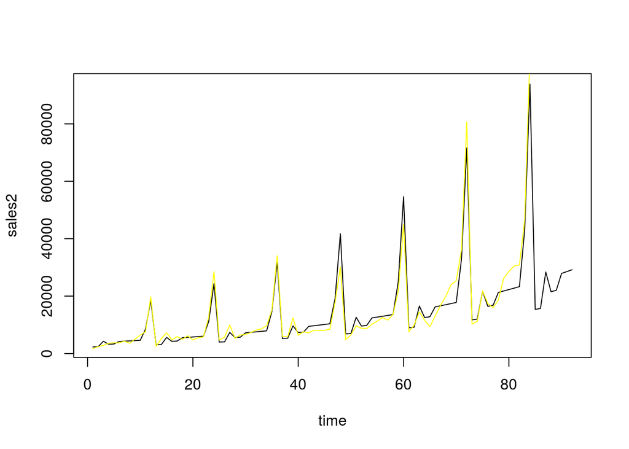